# Data Quality Report: Credit Card Payment

Bryce Charette

## Clean data

```r
# Adjust column names
colnames(dat) <- c("rec_num","card_num","date","merch_num","merch_desc",
                   "merch_state","merch_zip","trans_type","amount","fraud")

# Adjust data types
dat$rec_num <- as.character(dat$rec_num)
dat$card_num <- as.character(dat$card_num)

# Save data
# saveRDS(dat, "card_payments.rds")
```

## Statistics & Distributions

### `rec_num`

- **Interpretation:** Unique ID for each record in the data set.
- **Type:** ID
- **Unique Values:** 95,484
- **Missing Values:** 0 (0.00%)
- **Mean:** `NA`
- **Standard Deviation:** `NA`
- **Distribution:** `NA`

### `card_num`

- **Interpretation:** Credit card number of credit card holder.
- **Type:** ID
- **Unique Values:** 1,638
- **Missing Values:** 0 (0.00%)
- **Mean:** `NA`
- **Standard Deviation:** `NA`
- **Distribution:** `NA`

### `date`

- **Interpretation:** Transaction date
- **Type:** Date
- **Unique Values:** 365
- **Missing Values:** 0 (0.00%)
- **Mean:** `NA`
- **Standard Deviation:** `NA`
- **Distribution:**

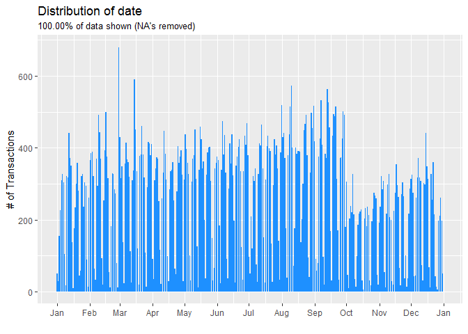

### `merch_num`

- **Interpretation:** Merchant ID
- **Type:** ID
- **Unique Values:** 13,091
- **Missing Values:** 3,351 (3.51%)
- **Mean:** `NA`
- **Standard Deviation:** `NA`
- **Distribution:**

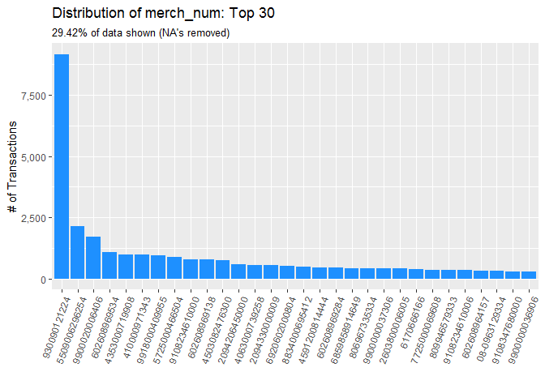

### `merch_desc`

- **Interpretation:** Merchant description
- **Type:** ID
- **Unique Values:** 13,125
- **Missing Values:** 0 (0.00%)
- **Mean:** `NA`
- **Standard Deviation:** `NA`
- **Distribution:**

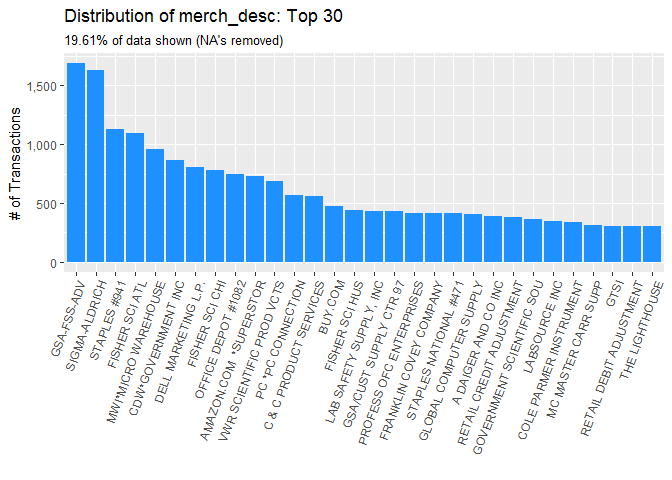

### `merch_state`

- **Interpretation:** Merchant state
- **Type:** Categorical
- **Unique Values:** 228
- **Missing Values:** 1,191 (1.25%)
- **Mean:** `NA`
- **Standard Deviation:** `NA`
- **Distribution:**

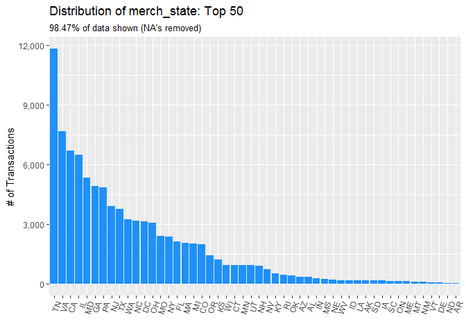

### `merch_zip`

- **Interpretation:** Merchant zipcode
- **Type:** Categorical
- **Unique Values:** 4,568
- **Missing Values:** 4,639 (4.86%)
- **Mean:** `NA`
- **Standard Deviation:** `NA`
- **Distribution:**

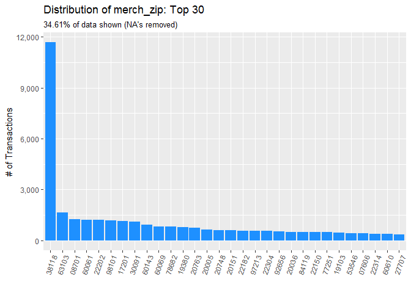

### `trans_type`

- **Interpretation:** Transaction type
- **Type:** Categorical
- **Unique Values:** 4
- **Missing Values:** 0 (0.00%)
- **Mean:** `NA`
- **Standard Deviation:** `NA`
- **Distribution:**

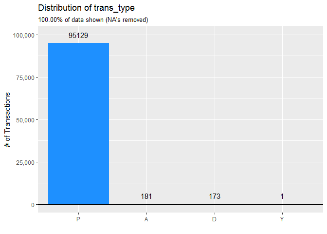

### `amount`

- **Interpretation:** Transaction amount in US dollars ($)
- **Type:** Numeric
- **Unique Values:** 34,190
- **Missing Values:** 0 (0.00%)
- **Mean:** $414.38
- **Standard Deviation:** $10,066.23
- **Min:** $0.01
- **Max:** $3,102,045.53
- **Distribution:**

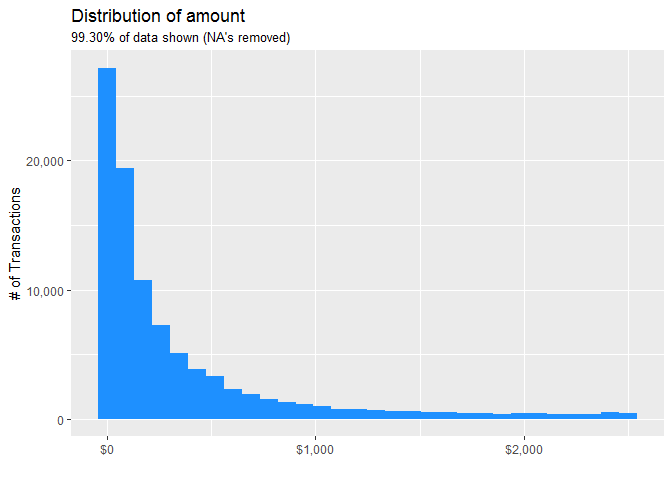

### `fraud`

- **Interpretation:** Indicator whether transaction is fraudulent
- **Type:** Categorical
- **Unique Values:** 2
- **Missing Values:** 0 (0.00%)
- **Mean:** `NA`
- **Standard Deviation:** `NA`
- **Distribution:**

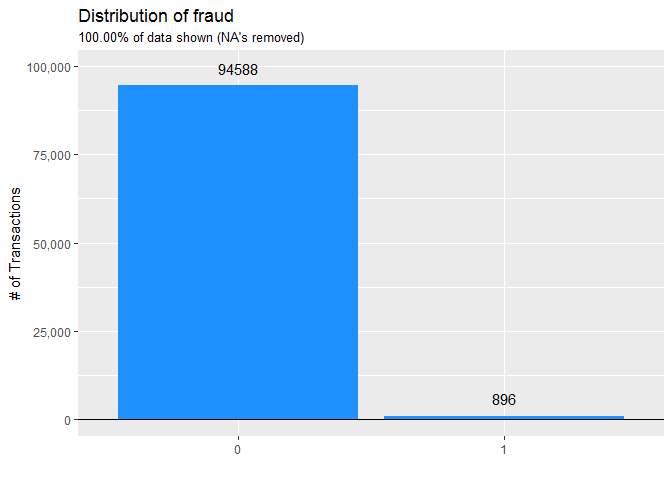